# Soc722 - SR Chapter 6

Turgut Keskintürk

2022-10-14

Hello there! Let’s start with our exercises for McElreath’s *Statistical Rethinking*, Chapter 6.

# 1 Easy Problems

## 1.1 5E1

Here are the three central mechanisms for false inferences:

- *Multicollinearity*, where the conditional associations among two or more variables are high to produce reliable interpretations.
- *Post-Treatment Bias*, which occurs when we control the consequences of a treatment, leaving the treatment no true variation to explain.
- *Collider Bias*, which occurs when we open up a path in the DAG that is actually close, which in turn creates spurious correlations.

## 1.2 5E2

Well, my research suffers from no such treacheries, Mr. McElreath, but I will give you an example:

Suppose that we want to explain the cultural transmission from institutional channels, where a religious authority $R$ influences a parent $P$, who in turn influences their child $C$, or $R$ influences $C$ directly.

However, the values of $P$ and $C$ can be affected by their household environment $H$, which is not shared by the $R$.

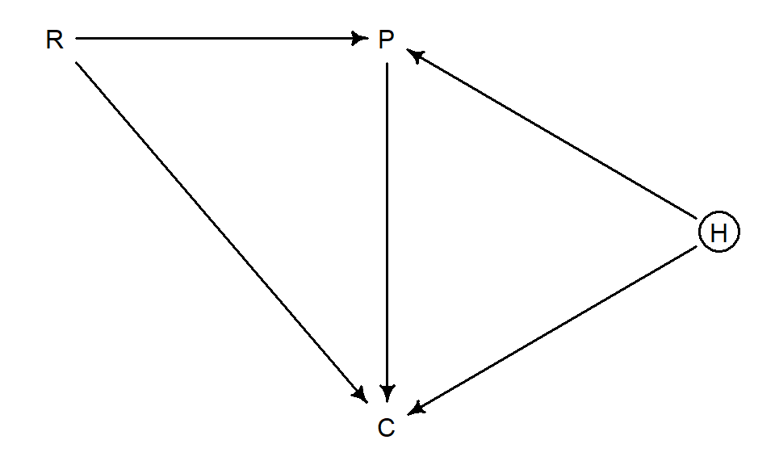

```r
dag.example <- dagitty("dag{H [unobserved]
       R -> P -> C
       R -> C
       H -> P
       H -> C}")
coordinates(dag.example) <- list(
  x = c(R = 0, P = 1, C = 1, H = 2),
  y = c(R = 0, P = 0, C = 2, H = 1)
)
drawdag(dag.example)
```

As you might notice, this example is a rework of the one we saw as the Grandparent-Parent-Child example. Conditioning on $P$ thus will bias the relation between $R$ and $C$ by opening the path for $H$ to intervene, which in turn creates a collider bias.

This set-up (as we’ll see below) applies to many sampling issues as well (think of non-responses, list-wise deletion, etc.).

## 1.3 5E3

I will list the four elemental confounds. What a name, though?

- **The Fork**, where a variable $Z$ is a common cause of both $X$ and $Y$.

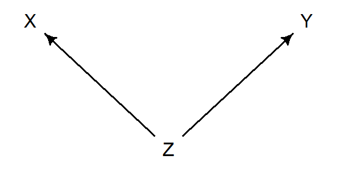

```r
dag.fork <- dagitty("dag{
       Z -> X
       Z -> Y}")
coordinates(dag.fork) <- list(
  x = c(X = 0, Y = 2, Z = 1),
  y = c(X = 0, Y = 0, Z = 1)
)
drawdag(dag.fork)
```

```r
impliedConditionalIndependencies(dag.fork)
```

```
## X _||_ Y | Z
```

As we see, conditioning on $Z$ makes $X$ and $Y$ orthogonal, as it blocks the non-causal path between these two variables.

- **The Pipe**, where a middle variable $Z$ connects $X$ to $Y$, and if we condition on $Z$, it will block this path.

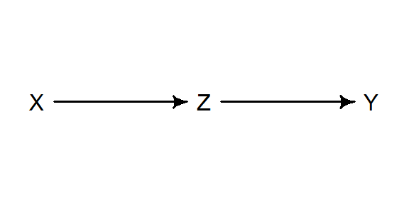

```r
dag.pipe <- dagitty("dag{
       X -> Z -> Y}")
coordinates(dag.pipe) <- list(
  x = c(X = 0, Y = 2, Z = 1),
  y = c(X = 0, Y = 0, Z = 0)
)
drawdag(dag.pipe)
```

```r
impliedConditionalIndependencies(dag.pipe)
```

```
## X _||_ Y | Z
```

Once more, conditioning on $Z$ made $X$ and $Y$ orthogonal. Before, the causal model implied that this conditioning actually discarded spurious correlation. Now, we see a blocking from $X$ and $Y$, simply because $Z$ explains this relation away.

- **The Collider**, which creates a spurious correlation between $X$ and $Y$ *if* we condition on $Z$.

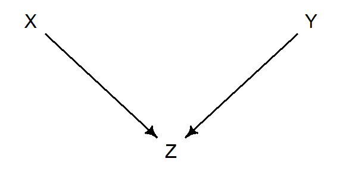

```r
dag.collider <- dagitty("dag{
       X -> Z
       Y -> Z}")
coordinates(dag.collider) <- list(
  x = c(X = 0, Y = 2, Z = 1),
  y = c(X = 0, Y = 0, Z = 1)
)
drawdag(dag.collider)
```

```r
impliedConditionalIndependencies(dag.collider)
```

```
## X _||_ Y
```

As we can see, $X$ and $Y$ are already orthogonal w/o any conditioning (meaning that the path is closed). If we condition on $Z$, we open this path, creating a non-causal and spurious relationship between $X$ and $Y$. Better lock the doors.

- **The Descendant** means a variable $D$ influenced by another variable $Z$, so if we condition on $D$, we partly condition on $Z$.

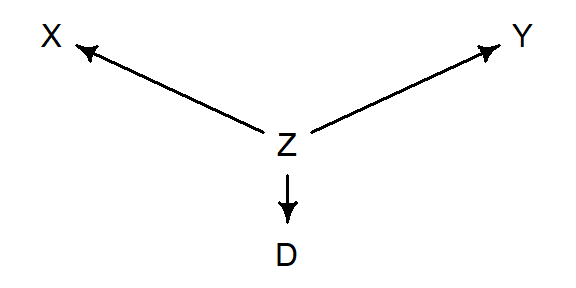

```r
dag.desc <- dagitty("dag{
       Z -> X
       Z -> Y
       Z -> D}")
coordinates(dag.desc) <- list(
  x = c(X = 0, Y = 2, Z = 1, D = 1),
  y = c(X = 0, Y = 0, Z = 1, D = 2)
)
drawdag(dag.desc)
```

```r
impliedConditionalIndependencies(dag.desc)
```

```
## D _||_ X | Z
## D _||_ Y | Z
## X _||_ Y | Z
```

If we condition on $Z$ in this model, all relations become orthogonal. Let’s try to understand that.

First, there is no relationship between $X$ and $Y$, but there is a path through $Z$, which creates a spurious relationship between these two variables. If we condition on $Z$, we block this path and discard that spurious relationship.

Similarly, there are paths from (a) $X$ and $D$ and (b) $Y$ and $D$, which are closed if we condition on $Z$.

## 1.4 5E4

Suppose that we conduct a survey to explain the effects of college drop-out $C$ on subsequent earnings $E$. Some people did not participate in the survey, which creates the response rate $R$.

Let us also assume that $C$ decreases response rate and $E$ increases response rate, meaning that both has an effect on $R$.

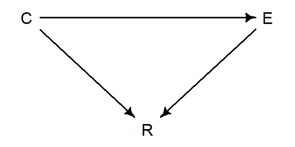

```r
dag.sampling <- dagitty("dag{
       C -> R
       E -> R
       C -> E}")
coordinates(dag.sampling) <- list(
  x = c(C = 0, E = 2, R = 1),
  y = c(C = 0, E = 0, R = 1)
)
drawdag(dag.sampling)
```

If we decide analyzing only the completed surveys by dropping those that did not answer, we effectively condition on $R$ (the response rate). This is similar to the *Berkson’s Paradox* example where the committee selects individuals in a non-random way.

Having a biased sample is thus a form of collider bias, which creates an endogenous selection into the sample.

# 2 Medium Problems

## 2.1 5M1

We are going to modify the DAG on p. 186 by including an unobserved $V$, cause of $C$ and $Y$: $C$ <- $V$ -> $Y$. First, the old version:

```r
dag.p186.v1 <- dagitty("dag{
       U [unobserved]
       X -> Y
       X <- U <- A -> C -> Y
       U -> B <- C}")
adjustmentSets(dag.p186.v1, exposure = "X", outcome = "Y")
```

```
## { C }
## { A }
```

As we can see, similar to the book, we need to condition on $C$ or $A$ in this case. Let’s rewrite and inspect:

```r
dag.p186.v2 <- dagitty("dag{
       U [unobserved]
       V [unobserved]
       X -> Y
       X <- U <- A -> C -> Y
       U -> B <- C
       C <- V -> Y}")
adjustmentSets(dag.p186.v2, exposure = "X", outcome = "Y")
```

```
## { A }
```

C is now out of the picture, and the DAG tells us that we should condition on $A$. Why did we lose $C$? Let’s draw the dag first:

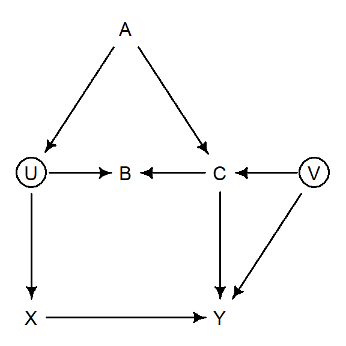

```r
coordinates(dag.p186.v2) <- list(
  x = c(X = 1, Y = 3, A = 2, B = 2, C = 3, U = 1, V = 4),
  y = c(X = 2, Y = 2, A = 0, B = 1, C = 1, U = 1, V = 1)
)
drawdag(dag.p186.v2)
```

As we can see, there are 5 paths in the DAG:

- $X$ -> $Y$, which is open, and we would like to keep it open.
- From $X$ to $Y$ through the nodes $U$, $B$, and $C$. This is, as we know, a collider, and it is closed, so we should keep it closed.
- There is also the path that goes through $A$, which is open as $A$ is a confounder, and it must be closed. Before, we could condition on $A$ or $C$ to close this path, but not $U$ (since it is unobserved), but $C$ is now connected to $V$, which creates complications.
- Two new paths include $V$, and both are closed, as $C$ is a collider now (see the triadic set $V$, $C$ and $A$). Will keep them closed!

## 2.2 5M2

A nice multicollinearity discussion! We are going to work on a structure of $X$ -> $Z$ -> $Y$. Let’s first simulate some data:

```r
set.seed(112358)

standardize <- function(x) {
  (x - mean(x)) / sd(x)
}

d <- tibble(
  x = rnorm(1000, 0, 1),
  z = rnorm(1000, x, 0.5),
  y = rnorm(1000, z, 0.5)
) %>%
  mutate(across(everything(), standardize))

cor(d)
```

```
##           x         z         y
## x 1.0000000 0.8887844 0.8207568
## z 0.8887844 1.0000000 0.9216151
## y 0.8207568 0.9216151 1.0000000
```

Cool! We have our data. As you can see, there is a strong correlation between $x$ and $z$. Let’s fit a model.

```r
quap(alist(
  y ~ dnorm(mu, sigma),
  mu <- a + b1 * x + b2 * z,
  a ~ dnorm(0, 1),
  b1 ~ dnorm(0, 1),
  b2 ~ dnorm(0, 1),
  sigma ~ dexp(1)
),
data = d) %>%
  precis() %>% round(2)
```

```
##       mean   sd  5.5% 94.5%
## a     0.00 0.01 -0.02  0.02
## b1    0.01 0.03 -0.03  0.05
## b2    0.91 0.03  0.87  0.96
## sigma 0.39 0.01  0.37  0.40
```

As we can see, all effects are piped through $z$, leaving $x$ no variation to explain.

This is not an example of multi-collinearity, simply because we know, through the DAG, that $x$ causes $z$, and there is no common cause that both causes $x$ and $z$ (like in the leg example). Our simulation structure also reflected that.

However, if we did not know the true data generation process, this high correlation could induce false modeling choices.

## 2.3 5M3

OK, just for practice, I am first going to draw these dags and save them to objects.

```r
rm(list = ls())

dag.1 <- dagitty("dag{
  Z <- A -> Y
  X <- Z -> Y
  X -> Y
  }")

dag.2 <- dagitty("dag{
  Z <- A -> Y
  X -> Z -> Y
  X -> Y
  }")

dag.3 <- dagitty("dag{
  Z <- A -> X
  X -> Z <- Y
  X -> Y
  }")

dag.4 <- dagitty("dag{
  Z <- A -> X
  X -> Z -> Y
  X -> Y
  }")
```

Cool! Before checking the answers, I will go through my reasonings for my expectations for each DAG. The one thing that I would like to emphasize is that the question wants us to evaluate the *total* causal effect, meaning that no mediation!

- **DAG 1**: $Z$ is a confounder, so we must condition on that. No need for others, since there is no backdoor to $X$.
- **DAG 2**: There is no backdoor to $X$, and conditioning on $Z$ would create a collider. So, no adjustment.
- **DAG 3**: There are three paths from $X$ to $Y$, but only one is open. Conditioning on $Z$ would create a collider, and that path is thus currently close. Condititioning on $A$ also would open that path, so let’s not do that, as well!
- **DAG 4**: There are three paths from $X$ to $Y$, and all paths are open this time. Since we want to learn the total effect, we should not adjust for $Z$. However, $A$ can confound our main path, so we must condition on that.

Let’s see if my reasonings are true.

```r
adjustmentSets(dag.1, exposure = "X", outcome = "Y", effect = "total")
```

```
## { Z }
```

```r
adjustmentSets(dag.2, exposure = "X", outcome = "Y", effect = "total")
```

```
##  {}
```

```r
adjustmentSets(dag.3, exposure = "X", outcome = "Y", effect = "total")
```

```
##  {}
```

```r
adjustmentSets(dag.4, exposure = "X", outcome = "Y", effect = "total")
```

```
## { A }
```

Cool!

# 3 Hard Problems

## 3.1 5H1

We are going to use the infamous Waffle House data. Let’s load it.

```r
data(WaffleDivorce)
d <- WaffleDivorce %>%
  select(
    reg = South,
    age = MedianAgeMarriage,
    div = Divorce,
    waf = WaffleHouses,
    mar = Marriage
  ) %>% mutate(across(-reg, rethinking::standardize))
rm(WaffleDivorce) # for clean-up
```

OK, the question wants us to measure the influence of $WaffleHouses$ on $Divorce$. Here is the causal graph I would propose (I add, of course, the *effects* of Waffle House on Divorce rate per this example).

[figure not shown]

```r
dag.waffle <- dagitty("dag{
       WaffleHouse -> Divorce
       South -> Marriage
       South -> MarriageAge
       South -> Divorce
       South -> WaffleHouse
       MarriageAge -> Divorce
       MarriageAge -> Marriage
       Marriage -> Divorce
       }")
coordinates(dag.waffle) <- list(
  x = c(WaffleHouse = 1, South = 2, MarriageAge = 2, Marriage = 3, Divorce = 3),
  y = c(WaffleHouse = 2, South = 0, MarriageAge = 1, Marriage = 1, Divorce = 2)
)
drawdag(dag.waffle)
```

OK, what should we condition on? The computers are good to think like that!

```r
adjustmentSets(dag.waffle, exposure = "WaffleHouse", outcome = "Divorce", effect = "total")
```

```
## { South }
```

It seems that I only need to condition on $South$ with this DAG. Let’s try.

```r
m.waffle <- quap(alist(
  div ~ dnorm(mu, sigma),
  mu <- a + b1 * waf + b2 * reg,
  a ~ dnorm(0, 1),
  b1 ~ dnorm(0, 1),
  b2 ~ dnorm(0, 1),
  sigma ~ dexp(1)
), data = d)

precis(m.waffle) %>% round(2)
```

```
##        mean   sd  5.5% 94.5%
## a     -0.17 0.16 -0.43  0.09
## b1     0.06 0.17 -0.21  0.34
## b2     0.61 0.37  0.02  1.20
## sigma  0.92 0.09  0.78  1.07
```

Nice! The model shows that, once we condition on $South$, the potential influence of $WaffleHouse$ are discarded right away.

## 3.2 5H2

We first need to look at the implied conditional independencies of the causal graph I used in the previous example.

```r
impliedConditionalIndependencies(dag.waffle)
```

```
## Mrrg _||_ WffH | Soth
## MrrA _||_ WffH | Soth
```

OK, there are two conditional independencies as far as we can see. Let’s test them one by one.

- Once we condition on $South$, the relationship between $WaffleHouses$ and $Marriage$ should be orthogonal.

```r
quap(alist(
  mar ~ dnorm(mu, sigma),
  mu <- a + b1 * waf + b2 * reg,
  a ~ dnorm(0, 1),
  b1 ~ dnorm(0, 1),
  b2 ~ dnorm(0, 1),
  sigma ~ dexp(1)
), data = d) %>%
  precis() %>% round(2)
```

```
##        mean   sd  5.5% 94.5%
## a     -0.06 0.17 -0.34  0.22
## b1    -0.04 0.18 -0.33  0.25
## b2     0.22 0.38 -0.40  0.83
## sigma  0.98 0.10  0.82  1.13
```

Look at the parameter $\beta_1$, which is imprecise around 0. **Judgment: orthogonal!**

- Once we condition on $South$, the relationship between $WaffleHouse$ and $MarriageAge$ should be orthogonal.

```r
quap(alist(
  age ~ dnorm(mu, sigma),
  mu <- a + b1 * waf + b2 * reg,
  a ~ dnorm(0, 1),
  b1 ~ dnorm(0, 1),
  b2 ~ dnorm(0, 1),
  sigma ~ dexp(1)
), data = d) %>%
  precis() %>% round(2)
```

```
##        mean   sd  5.5% 94.5%
## a      0.16 0.17 -0.11  0.43
## b1     0.06 0.18 -0.22  0.34
## b2    -0.58 0.38 -1.18  0.02
## sigma  0.95 0.09  0.80  1.10
```

Look at the parameter $\beta_1$, which is imprecise around 0. **Judgment: orthogonal!**

*Overall comment*: it seems that everything checks out!

## 3.3 Intermezzo

We are going to work with the `Foxes` data for questions 3, 4 and 5. Let’s clean our environment and load the data.

```r
rm(list = ls())
data(foxes)
d <- foxes %>%
  mutate(across(-group, standardize))
rm(foxes)

# let's inspect the data first
glimpse(d)
```

```
## Rows: 116
## Columns: 5
## $ group     <int> 1, 1, 2, 2, 3, 3, 4, 4, 5, 5, 5, 6, 6, 6, 7, 7, 7, 8, 8, 8, …
## $ avgfood   <dbl> -1.92482922, -1.92482922, -1.11803540, -1.11803540, -1.31973…
## $ groupsize <dbl> -1.5240888, -1.5240888, -1.5240888, -1.5240888, -1.5240888, …
## $ area      <dbl> -2.2395962, -2.2395962, -1.2055079, -1.2055079, -1.1301056, …
## $ weight    <dbl> 0.414134697, -1.427046423, 0.675954030, 1.300942116, 1.11513…
```

We are going to assume the following DAG for the upcoming models.

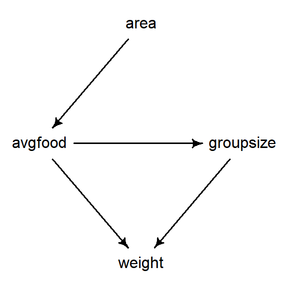

```r
dag.foxes <- dagitty("dag{
       area -> avgfood
       avgfood -> groupsize
       avgfood -> weight <- groupsize
       }")
coordinates(dag.foxes) <- list(
  x = c(area = 2, avgfood = 1, groupsize = 3, weight = 2),
  y = c(area = 0, avgfood = 1, groupsize = 1, weight = 2)
)
drawdag(dag.foxes)
```

## 3.4 5H3

We would like to infer the total causal influence of $area$ on $weight$. Let’s first try to establish our adjustment set.

```r
adjustmentSets(dag.foxes, exposure = "area", outcome = "weight", effect = "total")
```

```
##  {}
```

Cool! It seems that we do not need to adjust for any other variable. But bear in mind that the question asks us to find the *total* effect, which might change if we want to understand the mechanisms that underlie this effect!

Increasing the area available for each fox could help finding different food sources, but might make them more vulnerable to threats.

First, I want to make some prior predictive simulations to see whether my upcoming choices of priors are sensible.

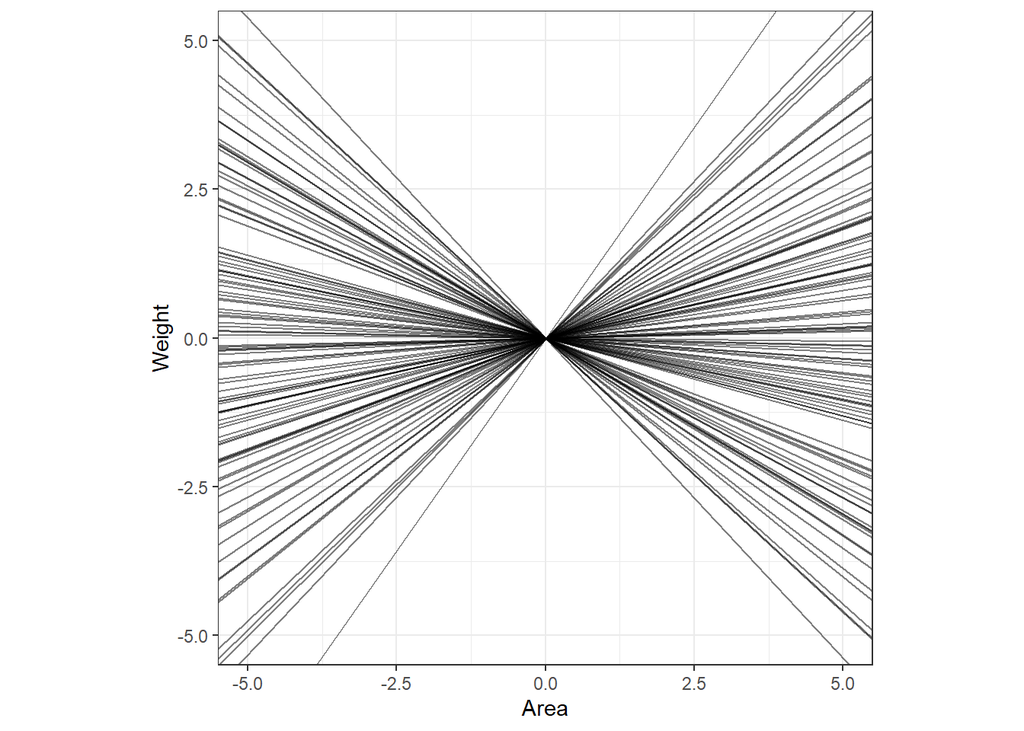

```r
set.seed(112358)

d.pps <- tibble(
  id = 1:100,
  a = rep(0, 100),
  b = rnorm(100, 0, 0.5),
  sigma = rexp(100, 1)
)

ggplot(d.pps) +
  geom_abline(aes(
    slope = b,
    intercept = a
  ),
  alpha = .5) +
  labs(x = "Area",
       y = "Weight") +
  xlim(-5, 5) +
  ylim(-5, 5) +
  theme(legend.position = "none") +
  theme(aspect.ratio = 1)
```

No weird stuff I’d say. Let’s fit our model to the data and inspect the results.

```r
quap(alist(
  weight ~ dnorm(mu, sigma),
  mu <- a + b * area,
  a ~ dnorm(0, 1),
  b ~ dnorm(0, 0.5),
  sigma ~ dexp(1)
), data = d) %>%
  precis() %>% round(2)
```

```
##       mean   sd  5.5% 94.5%
## a     0.00 0.09 -0.15  0.15
## b     0.02 0.09 -0.13  0.16
## sigma 0.99 0.06  0.89  1.09
```

The parameter estimation for $\beta$ shows that $area$ has no effect on $weight$ whatsoever.

## 3.5 5H4

```r
adjustmentSets(dag.foxes, exposure = "avgfood", outcome = "weight", effect = "total")
```

```
##  {}
```

No need! Cool. Let’s fit the model, then.

```r
quap(alist(
  weight ~ dnorm(mu, sigma),
  mu <- a + b * avgfood,
  a ~ dnorm(0, 1),
  b ~ dnorm(0, 0.5),
  sigma ~ dexp(1)
), data = d) %>%
  precis() %>% round(2)
```

```
##        mean   sd  5.5% 94.5%
## a      0.00 0.09 -0.15  0.15
## b     -0.02 0.09 -0.17  0.12
## sigma  0.99 0.06  0.89  1.09
```

Interestingly, no effect again (and I’m surprised!). What’s going on here?

## 3.6 5H5

This time, we are asked to retrieve the total causal impact of group size. First, the adjustment set:

```r
adjustmentSets(dag.foxes, exposure = "groupsize", outcome = "weight", effect = "total")
```

```
## { avgfood }
```

Huh! This time we need to condition on something. Which makes sense, actually! If we look at the DAG itself, we see that $avgfood$ is a confounder to the relation between $groupsize$ and $weight$. Let’s fit the model.

```r
m.grsize <- quap(alist(
  weight ~ dnorm(mu, sigma),
  mu <- a + b1 * avgfood + b2 * groupsize,
  a ~ dnorm(0, 1),
  b1 ~ dnorm(0, 0.5),
  b2 ~ dnorm(0, 0.5),
  sigma ~ dexp(1)
), data = d)

m.grsize %>% precis() %>% round(2)
```

```
##        mean   sd  5.5% 94.5%
## a      0.00 0.09 -0.14  0.14
## b1     0.48 0.18  0.19  0.76
## b2    -0.57 0.18 -0.86 -0.29
## sigma  0.94 0.06  0.84  1.04
```

So, $groupsize$ decreases the $weight$, while $avgfood$ increases it.

I am now going to look at the posterior distributions and plot the estimations.

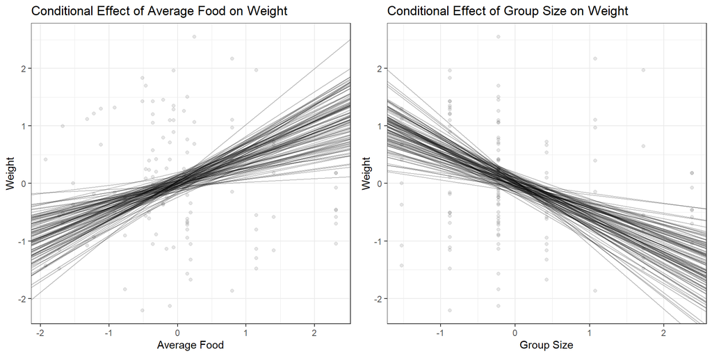

```r
# posterior draws
draws <- tidy_draws(m.grsize, n = 100) %>%
  select(a, b1, b2)

# plot for average food
p1 <- ggplot(draws) +
  geom_abline(aes(intercept = a, slope = b1), alpha = .25) +
  geom_point(
    data = d,
    mapping = aes(x = avgfood, y = weight),
    alpha = .1
  ) +
  labs(x = "Average Food", y = "Weight", title = "Conditional Effect of Average Food on Weight")

# plot for group size
p2 <- ggplot(draws) +
  geom_abline(aes(intercept = a, slope = b2), alpha = .25) +
  geom_point(
    data = d,
    mapping = aes(x = groupsize, y = weight),
    alpha = .1
  ) +
  labs(x = "Group Size", y = "Weight", title = "Conditional Effect of Group Size on Weight")

grid.arrange(p1, p2, nrow = 1)
```

## 3.7 5H6

Now, let’s go with our *own* research question. I just like a clean environment, so let’s do that.

```r
rm(list = ls())
```

One research question that I have in mind is to ask whether cultural transmission from a parent to a child occurs more successfully if the child sees father as having prestige. Here is a potential (and highly simplified, if I may) DAG that I have in mind.

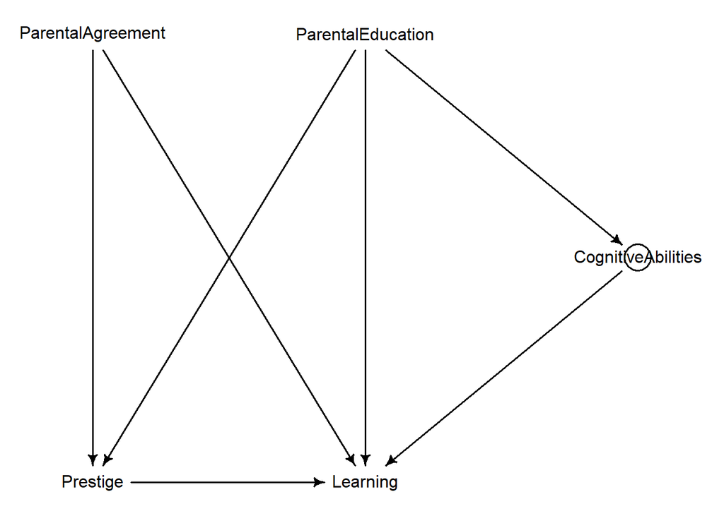

```r
dag.prestige <- dagitty("dag{
                        Prestige [exposure]
                        Learning [outcome]
                        CognitiveAbilities [unobserved]
                        Prestige -> Learning
                        ParentalEducation -> Prestige
                        ParentalEducation -> Learning
                        ParentalAgreement -> Prestige
                        ParentalAgreement -> Learning
                        CognitiveAbilities -> Learning
                        ParentalEducation -> CognitiveAbilities
                        }")
coordinates(dag.prestige) <- list(
  x = c(
    Prestige = 1,
    Learning = 2,
    ParentalEducation = 2,
    ParentalAgreement = 1,
    CognitiveAbilities = 3
  ),
  y = c(
    Prestige = 2,
    Learning = 2,
    ParentalEducation = 0,
    ParentalAgreement = 0,
    CognitiveAbilities = 1
  )
)
drawdag(dag.prestige)
```

This is probably a *very bad* model, but let’s go with this. Here are the testable implications and adjustment sets for the model.

```r
impliedConditionalIndependencies(dag.prestige)
```

```
## PrnA _||_ PrnE
```

```r
adjustmentSets(dag.prestige, effect = "total")
```

```
## { ParentalAgreement, ParentalEducation }
```

OK, as we can see, parental agreement and parental education are orthogonal, and we need to condition on both for a potential model.

I omitted a lot of variables, most particularly those that involve genetic characteristics and non-parental environmental factors. Hence, a reasonable college would punch me on every respect, but I think this is the job!

## 3.8 5H7

Let’s try a simulation.

```r
d <- tibble(
  ParentalAgreement = rnorm(1000, 0, 1),
  ParentalEducation = rnorm(1000, 0, 1),
  Prestige = rnorm(
    1000, 0.3*ParentalAgreement + 0.7*ParentalEducation, 1),
  CognitiveAbilities = rnorm(
    1000, 0.7*ParentalEducation, 1),
  Learning = rnorm(
    1000, 0.4*Prestige + 0.2*ParentalAgreement + 0.1*ParentalEducation + 0.3*CognitiveAbilities, 1)
)
```

OK, we know the effect sizes, but we do **not** observe the cognitive abilities. So I will try to fit two regressions with and w/o that variable to see how the coefficient estimates change when we omit $CognitiveAbilities$.

```r
# model fits

m1 <- quap(
  alist(
    Learning ~ dnorm(mu, sigma),
    mu <-
      a + b1 * Prestige + b2 * ParentalAgreement + b3 * ParentalEducation + b4 * CognitiveAbilities,
    a ~ dnorm(0, 1),
    b1 ~ dnorm(0, 0.5),
    b2 ~ dnorm(0, 0.5),
    b3 ~ dnorm(0, 0.5),
    b4 ~ dnorm(0, 0.5),
    sigma ~ dexp(1)
  ),
  data = d
)

m2 <- quap(
  alist(
    Learning ~ dnorm(mu, sigma),
    mu <-
      a + b1 * Prestige + b2 * ParentalAgreement + b3 * ParentalEducation,
    a ~ dnorm(0, 1),
    b1 ~ dnorm(0, 0.5),
    b2 ~ dnorm(0, 0.5),
    b3 ~ dnorm(0, 0.5),
    sigma ~ dexp(1)
  ),
  data = d
)
```

So, let’s extract the estimations and plot two models side by side. Using Pablo’s code again.

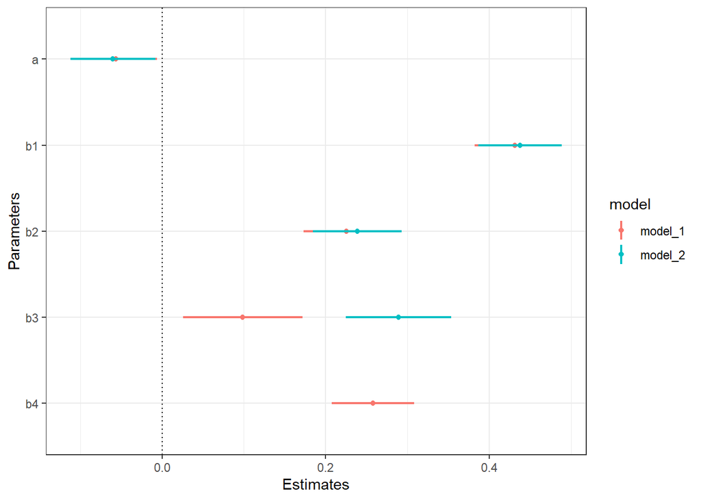

```r
# helper function
extract.coefs <- function(models) {
  lapply(1:length(models), function(x) {
    tbl <-
      precis(models[[x]]) # mean and compatibility intervals
    model <-
      names(models)[x] # the name of the model

    tbl %>%
      as_tibble() %>%
      mutate(coef = rownames(tbl),
             model = model) %>%
      relocate(model, coef)
  })
}

# extract model coefficients
modellist <- list(model_1 = m1,
                  model_2 = m2)
modelcoef <- extract.coefs(modellist) %>%
  bind_rows() %>%
  janitor::clean_names()

# plot
modelcoef %>%
  filter(coef != "sigma") %>% # don't wanna plot sigma
  mutate(coef = factor(coef, levels = c("sigma", "b4", "b3", "b2", "b1", "a"))) %>%
  ggplot(aes(x = mean,
             y = coef,
             group = model,
             color = model,
             xmin = x5_5_percent,
             xmax = x94_5_percent)) +
  geom_point(size = 1.5) +
  geom_linerange(size = 0.75) +
  geom_vline(
    aes(xintercept = 0),
    size = 0.5,
    linetype = "dotted",
    color = "black"
  ) +
  labs(x = "Estimates", y = "Parameters")
```

As we can see, most of what $CognitiveAbilities$ would explain is subsumed under $ParentalEducation$, inflating the coefficient estimate of the latter, even though the influence was actually came from the former.

Thank you!